# MACHINE LEARNING - CLASSIFICAÇÃO COM k-NN

Autor

João Ricardo F. de Lima

Data de Publicação

9 de abril de 2024

# Introdução

[^1] Em termos gerais, **Machine Learning (ML)** se refere a um vasto conjunto de técnicas para entender os dados. Essas técnicas podem ser classificadas em supervisionadas ou não supervisionadas.

*Métodos supervisionados* envolvem construir modelos estatísticos para previsão ou simplesmente estimação de uma variável de interesse (um output) em função de uma ou mais variáveis explicativas (ou inputs). Dado um conjunto de dados, um algoritmo de aprendizado supervisionado busca otimizar um função - o modelo - de modo a encontrar uma combinação de valores que resultam no output esperado.

| Algoritmos de ML | Função |
| --- | --- |
| Nearest Neighbor | Classificação |
| Naive Bayes | Classificação |
| Decision Trees | Classificação |
| Classification Rule Learners | Classificação |
| Linear Regression | Previsão numérica |
| Regression Trees | Previsão numérica |
| Model Trees | Previsão numérica |
| Neural Networks | Uso dual |
| Support Vector Machine | Uso dual |

Já nos *métodos não supervisionados*, se tem apenas inputs e não tem-se outputs. Nesses, o objetivo é aprender sobre relações e estruturas envolvendo as variáveis consideradas. Um exemplo é a análise de conglomerados (clusters).

Finalmente, tem-se uma classe de algoritmos de ML conhecida como **meta-aprendizagem**. Esta não está associada a uma tarefa de aprendizado específica, mas por outro lado está focada em como aprender mais efetivamente.

| Algoritmos de ML | Função |
| --- | --- |
| Bagging | Uso dual |
| Boosting | Uso dual |
| Random Forests | Uso dual |

## Classificação usando algoritmos K-NN

Em termos simples, classificadores **nearest neighbor** - vizinho mais próximo - são definidos pela sua característica de classificar exemplos não rotulados atribuindo a eles a classe de exemplos rotulados similares. A despeito dessa definição simples, os métodos *nearest neighbor* são extremamente poderosos. Eles têm sido bem sucedidos em:

- Reconhecimento facial em vídeos e imagens;
- Prever se uma pessoa irá gostar de um filme ou música recomendada;
- Identificar padrões em dados genéticos.

Em geral, classificadores **nearest neighbor** são bem adequados para tarefas de classificação. O método de **nearest neighbor** para classificação é exemplificado pelo algoritmo **k-nearest neighbor** (k-NN). Embora seja um dos mais simples algoritmos de ML, ele ainda é bastante utilizado. A seguir os pontos fortes e fracos dessa abordagem:

**Pontos fortes**:

- Simples e efetivo;
- Não faz suposição sobre a distribuição dos dados;
- Fase de treino rápida.

**Pontos fracos**:

- Não há produção de modelo;
- Requer a seleção de um k apropriado;
- Fase de classificação lenta;
- Características nominais e missing data requerem processamento adicional.

O algoritmo k-NN tem esse nome do fato de que ele usa informação de um exemplo k-nearest neighbors para classificar exemplos não rotulados. A letra **k** é um termo variável implicando que qualquer número de vizinhos próximos pode ser utilizado. Após escolher *k*, o algoritmo requer um dataset de treino contendo exemplos que são classificados em diferentes categorias, rotulados por uma variável nominal. Assim, para cada registro não rotulado no dataset de teste, o algoritmo k-NN identifica *k* registros no dataset de treino que estão mais próximos em similaridade. O exemplo de teste não rotulado é então atribuído à classe da maioria dos k vizinhos mais próximos.

## Como o k-NN funciona?

**Pseudocódigo:**

**Algoritmo** *k-vizinhos próximos* é:

**Entrada**:

- Conjunto de dados de treino $F = {(x_1, y_1), \dots, (x_n, y_n)}$,
  - $x$ = valor de um atributo da observação
  - $y$ = classe da observação
- Número $k$ de vizinhos próximos,
- Métrica de distância $d(x,y)$,
- Conjunto de dados de teste $X$ para classificar.

**Saída**:

- Classificação da observação $X$.

**Início**

**para** cada amostra de treino $(x_i, y_i) \in F$ faça

> Calcular $d(X, x_i)$, a distância entre $X$ e $x_i$

Deixe $N \subseteq F$ ser o conjunto de treinamento com as $k$ menores distâncias $d(X, x_i)$

**retorne** a classe mais frequente em $N$

**Fim**

### Exemplo numérico

- **Aplicação**: descobrir o tipo da comida em um *jantar às cegas*.
- **Distância euclidiana**:

$$d(p,q) = \sqrt{\sum_{i=1}^{n}(p_i-q_i)^2}$$

| Ingrediente | Doçura | Crocância | Tipo |
| --- | --- | --- | --- |
| bacon | 1 | 4 | proteína |
| banana | 10 | 1 | fruta |
| cenoura | 7 | 10 | vegetal |
| alface | 2 | 10 | vegetal |
| queijo | 1 | 1 | proteína |
| uva | 8 | 5 | fruta |
| feijão | 3 | 7 | vegetal |
| nozes | 3 | 6 | proteína |
| laranja | 7 | 3 | fruta |

- **Nova observação**: *tomate* com doçura = 6 e crocância = 4

| Ingrediente | Doçura | Crocância | Tipo | Distância |
| --- | --- | --- | --- | --- |
| bacon | 1 | 4 | proteína | $\sqrt{(6-1)^2 + (4-4)^2}=5$ |
| banana | 10 | 1 | fruta | $\sqrt{(6-10)^2 + (4-1)^2}=5$ |
| cenoura | 7 | 10 | vegetal | $\sqrt{(6-7)^2 + (4-10)^2}=6.1$ |
| alface | 2 | 10 | vegetal | $\sqrt{(6-2)^2 + (4-10)^2}=7.2$ |
| queijo | 1 | 1 | proteína | $\sqrt{(6-1)^2 + (4-1)^2}=5.8$ |
| uva | 8 | 5 | fruta | $\sqrt{(6-8)^2 + (4-5)^2}=2.2$ |
| feijão | 3 | 7 | vegetal | $\sqrt{(6-3)^2 + (4-7)^2}=4.2$ |
| nozes | 3 | 6 | proteína | $\sqrt{(6-3)^2 + (4-6)^2}=3.6$ |
| laranja | 7 | 3 | fruta | $\sqrt{(6-7)^2 + (4-3)^2}=1.4$ |

Para **classificar** a nova observação *tomate*:

- Com $k = 1$: *tomate* é **fruta** pois a laranja é o vizinho mais próximo (distância de 1.4) e é uma fruta;
- Com $k = 2$: *tomate* é **fruta** pois a laranja e a uva são os vizinhos mais próximos (distância de 1.4 e 2.2)) e a classe mais frequente é fruta;
- Com $k = 3$: *tomate* é **fruta** pois laranja, uva e nozes são os vizinhos mais próximos (distância de 1.4, 2.2 e 3.6) e a classe mais frequente é fruta;
- Etc…

Prática comum: escolher $k$ como a raiz quadrada do número de amostras de treino.

A decisão de quantos vizinhos usar para o algoritmo `k-NN` determinará quão bem o modelo irá gerar os dados futuros. O balanço entre `overfitting` e `underfitting` o dataset de treino é um problema conhecido como **bias-variance tradeoff**. *Overfitting* é um termo usado em estatística para descrever quando um modelo estatístico se ajusta muito bem ao conjunto de dados anteriormente observado, mas se mostra ineficaz para prever novos resultados. Por outro lado, *underfitting* ocorre quando o modelo não se adapta bem sequer aos dados com os quais foi treinado.

O *tradeoff* de *viés e variância* é a propriedade de um conjunto de modelos preditivos em que os modelos com um viés menor na estimativa de parâmetros têm uma variância maior das estimativas de parâmetros entre as amostras e vice-versa.

A escolha de um k alto, nesse contexto, reduz o impacto ou variância causada por dados que sejam ruídos, mas pode viesar o aprendizado. Por outro lado, utilizar um único vizinho mais próximo permite que dados ruidosos ou *outliers* influenciem a classificação de exemplos. O melhor valor para k, portanto, será algo entre esses dois extremos.

### Exemplo de k-vizinhos mais próximos: classificação econômica

Nessa seção apresenta-se um exemplo do algoritmo k-vizinhos mais próximos.

O **problema** utilizado nesse exemplo é o seguinte:

- Deseja-se distinguir os países do mundo, em termos de desempenho econômico, em 3 categorias: economias avançadas, economias emergentes e economias de baixa renda.
- A finalidade da classificação é informacional: é mais fácil analisar e comparar o desempenho econômico de países dentro de uma mesma economia, além de servir como insumo para outros tipos de classificação, como, por exemplo, o risco de crédito soberano.

Os **pré-processamentos** de dados realizados são:

- É utilizada a amostragem aleatória estratificada para separar duas amostras: 70% para treino e o restante para teste.
- Valores extremos do PIB, detectados pela regra de corte IQR sugerida por Hyndman e Athanasopoulos (2021), são removidos das amostras;

Uma **visualização de dados**, antes da separação das amostras e remoção de valores extremos, é exibida abaixo:

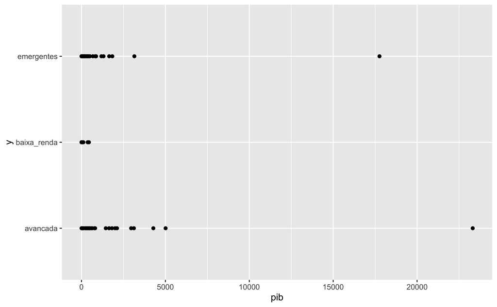

```r
# Carrega pacotes
library(rio)
library(rdbnomics)
library(dplyr)
library(tidyr)
library(splitTools)
library(ggplot2)
library(class)
library(caret)

# Carrega dados
dados_brutos_y <- rio::import(
  file = "https://www.imf.org/external/datamapper/Metadata_Oct2023.xlsx",
  format = "xlsx",
  setclass = "tibble",
  sheet = "Table A. Economy Groupings",
  col_types = c(rep("text", 3), rep("skip", 16)),
  n_max = 95
  )
dados_brutos_x <- rdbnomics::rdb(
  api_link = paste0(
    "https://api.db.nomics.world/v22/series/IMF/WEO:2023-10?",
    "dimensions=%7B%22unit%22%3A%5B%22us_dollars%22%5D%2C%22",
    "weo-subject%22%3A%5B%22NGDPD%22%5D%7D&observations=1"
    )
  )

# Pré-processamentos
dados_y <- dados_brutos_y |>
  dplyr::rename(
    "avancada" = "Advanced Economies",
    "emergentes" = "Emerging\r\nMarket Economies\r\n",
    "baixa_renda" = "Low-Income Developing\r\nCountries\r\n"
    ) |>
  tidyr::pivot_longer(
    cols = dplyr::everything(),
    names_to = "y",
    values_to = "pais"
    ) |>
  tidyr::drop_na()

dados_x <- dados_brutos_x |>
  dplyr::as_tibble() |>
  dplyr::group_by(`weo-country`) |>
  dplyr::filter(!is.na(value)) |>
  dplyr::filter(period == as.Date("2021-01-01")) |>
  dplyr::ungroup() |>
  dplyr::select("pais" = "WEO Country", "pib" = "value")

dados <- dplyr::left_join(x = dados_y, y = dados_x, by = "pais") |>
  tidyr::drop_na()

# Visualização de dados
dados |>
  ggplot2::ggplot() +
  ggplot2::aes(x = pib, y = y) +
  ggplot2::geom_point()
```

As **classificações** do algoritmo k-vizinhos mais próximos são exibidas abaixo:

```r
# Separação de amostras
set.seed(1984)
amostras <- splitTools::partition(
  y = dados$y,
  p = c(treino = 0.7, teste = 0.3),
  type = "stratified"
  )

dados_treino <- dados[amostras$treino, ]
dados_teste <- dados[amostras$teste, ]

# Função para computar regra de corte IQR
regra_iqr <- function(x, side) {
  if (side == "lower") {
    lower <- quantile(x = x, probs = 0.25, na.rm = TRUE) - 1.5 * IQR(x = x, na.rm = TRUE)
    return(lower)
  } else if (side == "upper") {
    upper = quantile(x = x, probs = 0.75, na.rm = TRUE) + 1.5 * IQR(x = x, na.rm = TRUE)
    return(upper)
  } else stop("side tem que ser lower ou upper")
}

# Filtra dados
dados_treino <- dados_treino |>
  dplyr::filter(
    !pib < regra_iqr(pib, "lower") & !pib > regra_iqr(pib, "upper")
    )
dados_teste <- dados_teste |>
  dplyr::filter(
    !pib < regra_iqr(pib, "lower") & !pib > regra_iqr(pib, "upper")
    )

# Classificação por k-vizinhos próximos
classificacao_teste <- class::knn(
  train = dados_treino[, 3],
  test = dados_teste[, 3],
  cl = factor(dados_treino$y),
  k = as.integer(sqrt(nrow(dados_treino)))
  )
classificacao_teste
```

```
 [1] emergentes  emergentes  emergentes  emergentes  baixa_renda baixa_renda
 [7] emergentes  emergentes  emergentes  emergentes  baixa_renda emergentes
[13] emergentes  emergentes  emergentes  baixa_renda emergentes  emergentes
[19] emergentes  emergentes  emergentes  emergentes  emergentes  emergentes
[25] baixa_renda baixa_renda emergentes  emergentes  baixa_renda emergentes
[31] baixa_renda baixa_renda emergentes  emergentes  baixa_renda emergentes
[37] baixa_renda baixa_renda baixa_renda emergentes  emergentes  emergentes
[43] emergentes  emergentes  emergentes  emergentes  emergentes  emergentes
[49] emergentes  baixa_renda
Levels: avancada baixa_renda emergentes
```

Por fim reportam-se **medidas de acurácia**:

```r
# Medidas de acurácia
caret::confusionMatrix(classificacao_teste, factor(dados_teste$y))
```

```
Confusion Matrix and Statistics

             Reference
Prediction    avancada baixa_renda emergentes
  avancada           0           0          0
  baixa_renda        2           7          5
  emergentes         5          10         21

Overall Statistics

               Accuracy : 0.56
                 95% CI : (0.4125, 0.7001)
    No Information Rate : 0.52
    P-Value [Acc > NIR] : 0.33635

                  Kappa : 0.1704

 Mcnemar's Test P-Value : 0.03407

Statistics by Class:

                     Class: avancada Class: baixa_renda Class: emergentes
Sensitivity                     0.00             0.4118            0.8077
Specificity                     1.00             0.7879            0.3750
Pos Pred Value                   NaN             0.5000            0.5833
Neg Pred Value                  0.86             0.7222            0.6429
Prevalence                      0.14             0.3400            0.5200
Detection Rate                  0.00             0.1400            0.4200
Detection Prevalence            0.00             0.2800            0.7200
Balanced Accuracy               0.50             0.5998            0.5913
```

## Notas de rodapé

[^1]: Todo este material foi retirado de diversas postagens da Análise Macro (www.analisemacro.com.br)
[^2]: Veja https://www.imf.org/en/Publications/FM/Issues/2023/10/10/fiscal-monitor-october-2023